# Breathing Without Help

ARI Child Health Care-Seeking Across the World

Author

Sooryadev Suresh

## Introduction

Children under the age of five are still affected by acute respiratory infections (ARI), which continue to be a primary source of disease for this age group. Access to health care for children who have ARIs varies dramatically from one country to another.

In order to assess the inequity that exists when it comes to seeking medical treatment for ARI, we will use UNICEF’s data with an emphasis on looking at the difference globally; how much does the level of economic development impact the ability of parents to seek medical treatment for their children who suffer from ARI; and changes in the way that parents seek medical treatment for their children suffering from ARI over time.

## Load libraries

```python
import pandas as pd
import numpy as np
from plotnine import *
```

## Load the data

```python
indicator = pd.read_csv("unicef_indicator_1.csv")
metadata = pd.read_csv("unicef_metadata.csv")
```

## Prepare the ARI dataset

```python
ari = indicator.copy()

ari = ari.rename(columns={
    "time_period": "year",
    "obs_value": "care_rate"
})

ari["year"] = pd.to_numeric(ari["year"], errors="coerce")
ari["care_rate"] = pd.to_numeric(ari["care_rate"], errors="coerce")

if "sex" in ari.columns and "Total" in ari["sex"].astype(str).unique():
    ari = ari[ari["sex"] == "Total"]

ari = ari.dropna(subset=["country", "alpha_3_code", "year", "care_rate"])
ari["year"] = ari["year"].astype(int)
```

## Prepare the metadata

```python
gdp = metadata[[
    "country",
    "alpha_3_code",
    "year",
    "GDP per capita (constant 2015 US$)"
]].copy()

gdp = gdp.rename(columns={
    "GDP per capita (constant 2015 US$)": "gdp_per_capita"
})

gdp["year"] = pd.to_numeric(gdp["year"], errors="coerce")
gdp["gdp_per_capita"] = pd.to_numeric(gdp["gdp_per_capita"], errors="coerce")

gdp = gdp.dropna(subset=["country", "alpha_3_code", "year"])
gdp["year"] = gdp["year"].astype(int)
```

## Merge the datasets

```python
df = ari.merge(
    gdp,
    on=["country", "alpha_3_code", "year"],
    how="left"
)
```

## Latest available value for each country

```python
latest = (
    df.sort_values(["country", "year"])
      .drop_duplicates(subset="country", keep="last")
      .copy()
)
```

## 1. Countries with highest and lowest care-seeking rates

This chart compares countries with the highest and lowest ARI care-seeking rates.

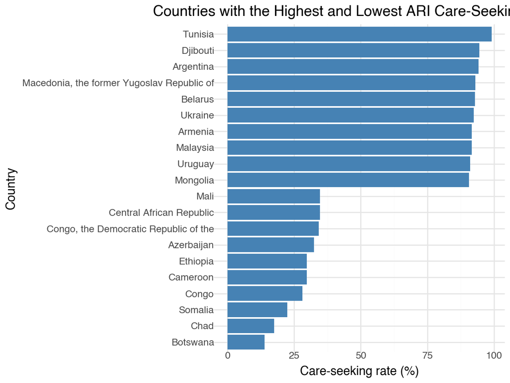

```python
top10 = latest.nlargest(10, "care_rate")
bottom10 = latest.nsmallest(10, "care_rate")
bar_df = pd.concat([top10, bottom10]).sort_values("care_rate")

(
    ggplot(bar_df, aes(x="reorder(country, care_rate)", y="care_rate"))
    + geom_col(fill="steelblue")
    + coord_flip()
    + labs(
        title="Countries with the Highest and Lowest ARI Care-Seeking Rates",
        x="Country",
        y="Care-seeking rate (%)"
    )
    + theme_minimal()
)
```

The large gap between countries highlights the unequal access to healthcare services globally.

## 2. GDP per capita and ARI care-seeking

This scatterplot examines whether wealthier countries have better access to healthcare.

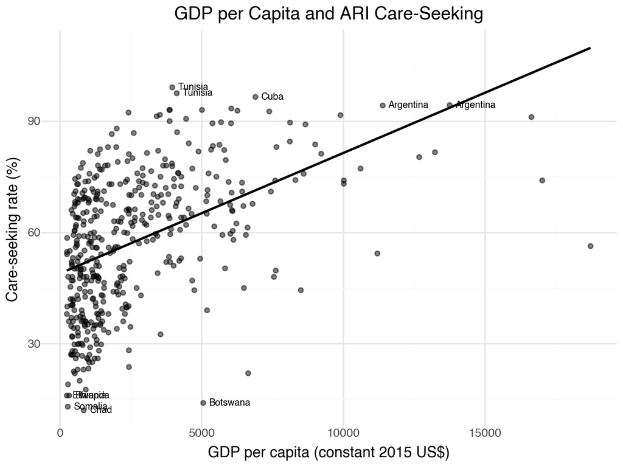

```python
scatter_df = df.dropna(subset=["gdp_per_capita", "care_rate"]).copy()

# Select a few countries to label (top + bottom performers)
label_df = pd.concat([
    scatter_df.nlargest(5, "care_rate"),
    scatter_df.nsmallest(5, "care_rate")
])

(
    ggplot(scatter_df, aes(x="gdp_per_capita", y="care_rate"))
    + geom_point(alpha=0.5)
    + geom_smooth(method="lm", se=False)
    + geom_text(
        data=label_df,
        mapping=aes(label="country"),
        size=7,
        ha="left",
        nudge_x=200
    )
    + labs(
        title="GDP per Capita and ARI Care-Seeking",
        x="GDP per capita (constant 2015 US$)",
        y="Care-seeking rate (%)"
    )
    + theme_minimal()
)
```

The upward trend suggests that higher-income countries generally have better access to healthcare, although the relationship is not perfect.

## 3. Average trend over time

This chart shows how global care-seeking rates have changed over time.

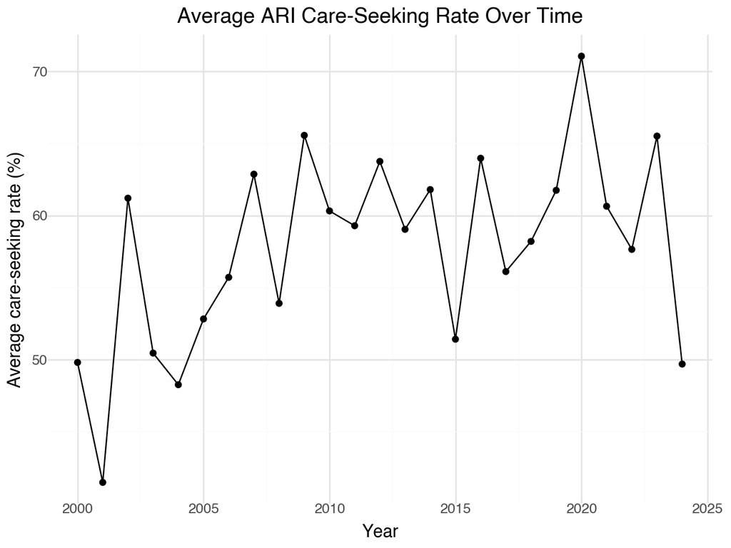

```python
trend = df.groupby("year", as_index=False)["care_rate"].mean()

(
    ggplot(trend, aes(x="year", y="care_rate"))
    + geom_line()
    + geom_point()
    + labs(
        title="Average ARI Care-Seeking Rate Over Time",
        x="Year",
        y="Average care-seeking rate (%)"
    )
    + theme_minimal()
)
```

The trend shows fluctuations over time, indicating that improvements in healthcare access are not consistent across years.

## 4. Country snapshot

This chart focuses on the 20 countries with the lowest most recent ARI care-seeking rates, making cross-country differences easier to read.

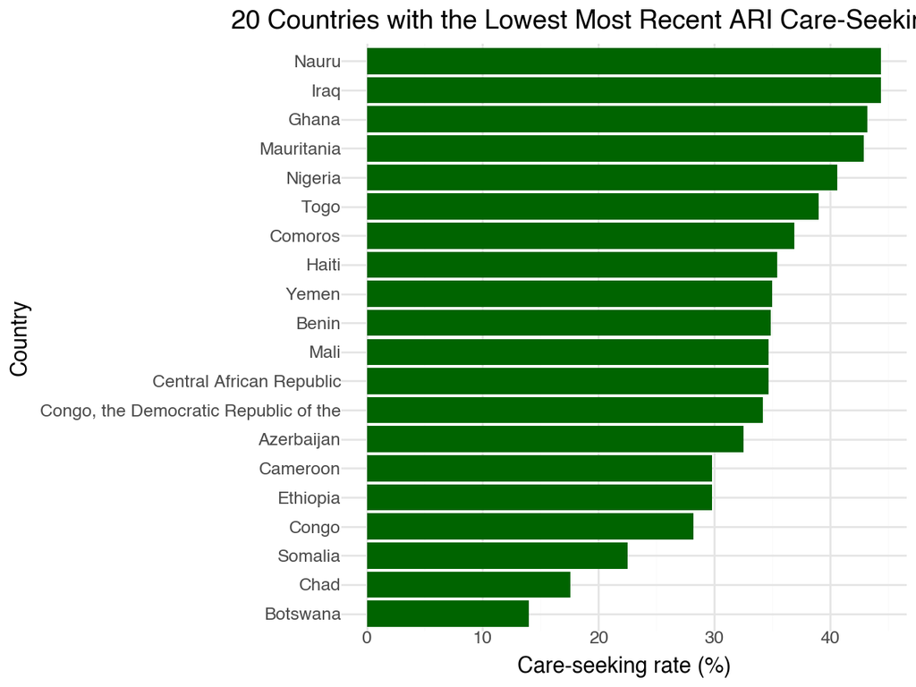

```python
snapshot20 = latest.nsmallest(20, "care_rate").sort_values("care_rate")

(
    ggplot(snapshot20, aes(x="reorder(country, care_rate)", y="care_rate"))
    + geom_col(fill="darkgreen")
    + coord_flip()
    + labs(
        title="20 Countries with the Lowest Most Recent ARI Care-Seeking Rates",
        x="Country",
        y="Care-seeking rate (%)"
    )
    + theme_minimal()
)
```

This focused view makes the countries with the weakest recent care-seeking outcomes easier to identify and compare.

## Conclusion

The data indicates that country-specific levels of ARI care-seeking are highly variable. Higher income countries generally provide greater access to healthcare than do lower-income countries; however, the level of a country’s economic development is an insufficient explanation for the differences observed in this study.

Global care-seeking trends indicate some positive trends over time, although disparities continue to exist. These results suggest the need for specific, evidence-based policy interventions as well as increased availability and accessibility of health-care services to address the disparity in child health outcomes.